# Stat 437 HW1

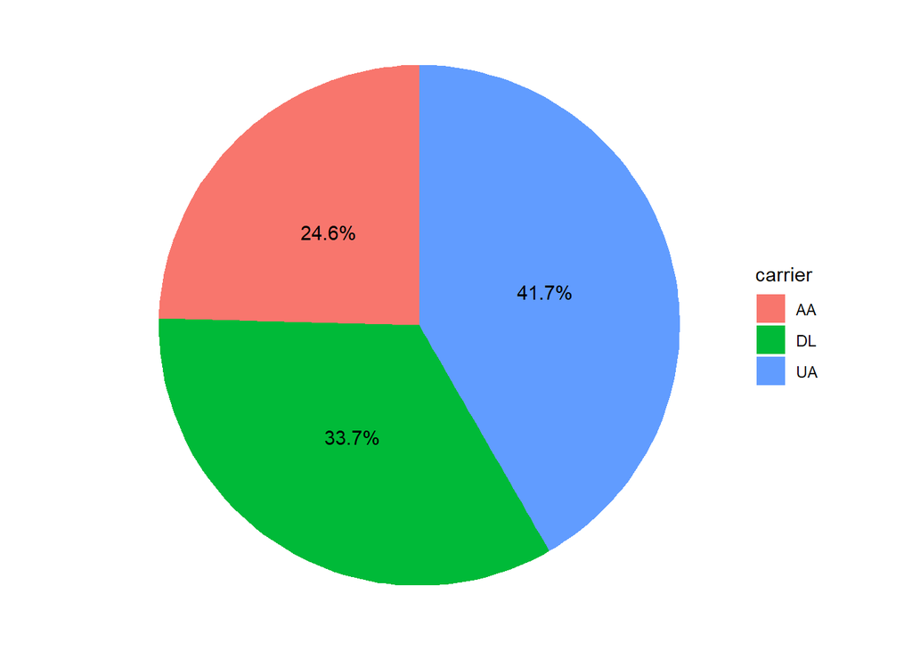

```r
pie = ggplot(sm2) + geom_bar(aes(x="", y =percentage, fill=carrier), stat="identity", width = 1)+coord_polar("y", start = 0) + theme_void() + geom_text(aes(x=1, y= cumsum(percentage)-percentage/2, label=labels))

print(pie)
```

```r
##Interpretation: The pie chart expresses that UA has 41.7%, DL has 33.7%, and AA has 24.6% of their observations.
```

(1.d) Plot `arr_delay` against `distance` with `facet_grid` designated by `month` and `carrier`.

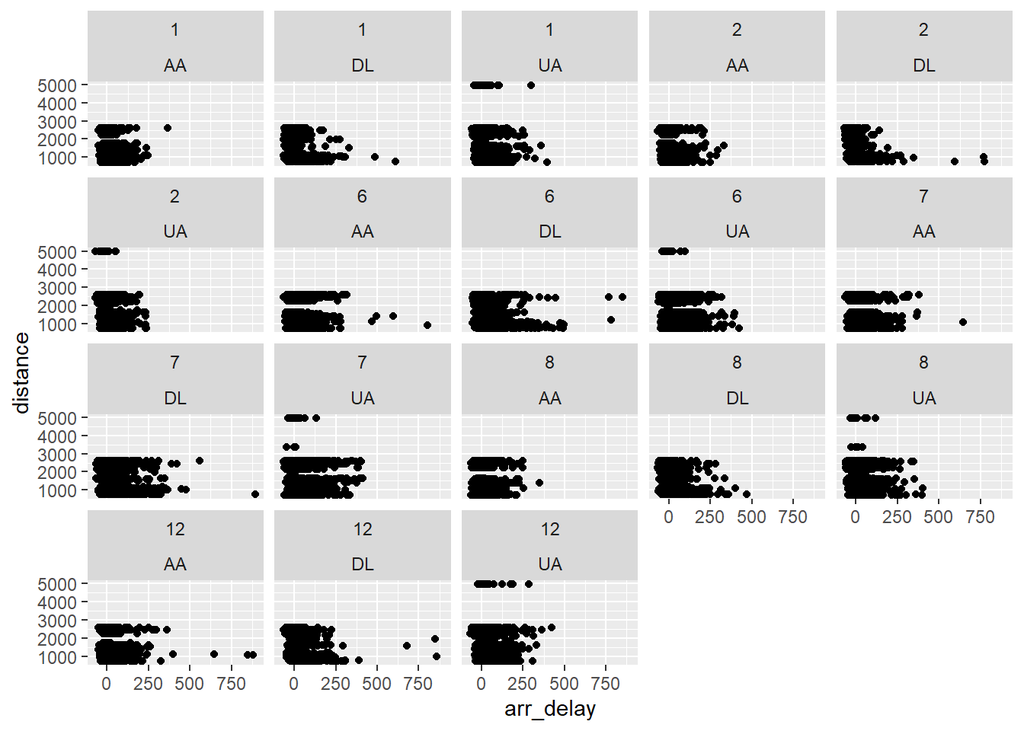

```r
plot1 = ggplot(data = temp) + geom_point(mapping = aes(x = arr_delay, y = distance))

plot2 = plot1 + facet_wrap(month~carrier, nrow = 4)

print(plot2)
```

```r
##Interpretation: Only UA carrier has the records of arriving delay with the long-distance flights.
```

(1.e) For each feasible combination of values of `month` and `carrier`, compute the sample average of `arr_delay` and save them into the variable `mean_arr_delay`, and compute the sample average of `distance` and save these averages into the variable `mean_distance`. Plot `month` against `mean_arr_delay` with `shape` designated by `carrier` and `color` by `mean_distance` and annotate each point by its associated `carrier` name.

```r
#obtain mean by each combination of month value and carrier
mean_arr_delay = temp %>% group_by(month, carrier) %>% summarise( mean_arr_delay = mean(arr_delay)) %>% as.data.frame()
print(mean_arr_delay)
```

```
##    month carrier mean_arr_delay
## 1      1      AA      1.1883167
## 2      1      DL     -4.0404784
## 3      1      UA      3.7168572
## 4      2      AA      1.0104530
## 5      2      DL     -4.6836803
## 6      2      UA      0.4696726
## 7      6      AA      6.5790090
## 8      6      DL     13.9477945
## 9      6      UA     12.2224950
## 10     7      AA      4.2829618
## 11     7      DL     15.3451183
## 12     7      UA     10.1627702
## 13     8      AA     -2.5087199
## 14     8      DL      1.3142706
## 15     8      UA      3.6292620
## 16    12      AA      7.5205479
## 17    12      DL      6.2163475
## 18    12      UA     14.0423901
```

```r
mean_distance = temp %>% group_by(month, carrier) %>% summarise( mean_distance = mean(distance)) %>% as.data.frame()
print(mean_distance)
```

```
##    month carrier mean_distance
## 1      1      AA      1407.774
## 2      1      DL      1317.234
## 3      1      UA      1601.036
## 4      2      AA      1404.979
## 5      2      DL      1312.187
## 6      2      UA      1570.462
## 7      6      AA      1392.524
## 8      6      DL      1356.091
## 9      6      UA      1698.521
## 10     7      AA      1381.290
## 11     7      DL      1362.119
## 12     7      UA      1708.035
## 13     8      AA      1378.601
## 14     8      DL      1352.149
## 15     8      UA      1722.198
## 16    12      AA      1415.697
## 17    12      DL      1323.626
## 18    12      UA      1657.657
```

```r
sm['mean_distance'] <- c(mean_distance)
print(sm)
```

```
##    month carrier mean_arr_delay mean_distance
## 1      1      AA      1.1883167             1
## 2      1      DL     -4.0404784             1
## 3      1      UA      3.7168572             1
## 4      2      AA      1.0104530             2
## 5      2      DL     -4.6836803             2
## 6      2      UA      0.4696726             2
## 7      6      AA      6.5790090             6
## 8      6      DL     13.9477945             6
## 9      6      UA     12.2224950             6
## 10     7      AA      4.2829618             7
## 11     7      DL     15.3451183             7
## 12     7      UA     10.1627702             7
## 13     8      AA     -2.5087199             8
## 14     8      DL      1.3142706             8
## 15     8      UA      3.6292620             8
## 16    12      AA      7.5205479            12
## 17    12      DL      6.2163475            12
## 18    12      UA     14.0423901            12
```

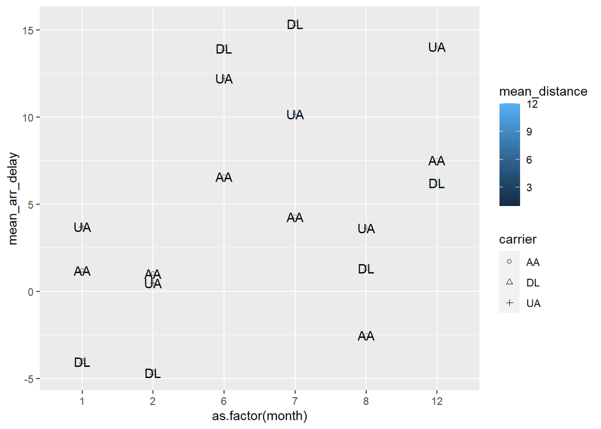

```r
#Plot `month` against `mean_arr_delay` with `shape` designated by `carrier` and `color` by `mean_distance`
# and annotate each point by its associated `carrier` name
pp3 = ggplot(sm, aes(x=as.factor(month), y = mean_arr_delay)) + geom_point(aes(as.factor(month), mean_arr_delay, colour = mean_distance, shape = carrier)) + geom_text(data=sm, aes(x=as.factor(month) , y=mean_arr_delay, label=carrier)) + scale_fill_distiller(palette = "YlOrBr") + scale_shape_manual(values = 1:length(unique(sm$carrier)) )

print(pp3)
```

```r
##Interpretation: DL is unstable and it delays pretty often in July.
```

# Problem 2

Please refer to the data set `mpg` that is available from the `ggplot2` package. Plot `displ` against `hwy` with faceting by `drv` and `cyl`, `color` disgnated by `class`, and `shape` by `trans`. This illustrates visualization with 4 factors.

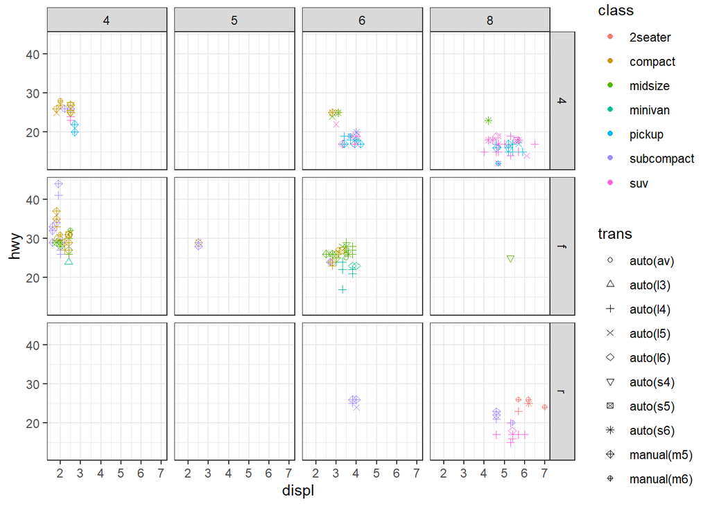

```r
#visualization with >= 3 factors

p1c = ggplot(mpg, aes(x = displ, y = hwy)) + theme_bw() + geom_point(aes(color=class, shape=trans)) + facet_grid(drv~cyl) + scale_shape_manual(values=c(1:10))

print(p1c)
```

```r
##Interpretation: Larger cars has more cylinders and higher engine displacement in litres, and the smaller cars requires less.
```